# STAT 118: Homework K

Intro to Maps

Author

```r
#LOAD PACKAGES
library(tidyverse)
library(sf) #this is a package needed so R can work with sf objects
library(maps)
```

# 1.

Use the `maps` package to create a map of New Zealand. To access map data for New Zealand use the code: `nz_maps <- map_data("world", region = "New Zealand")`. You may need to subset the latitude and longitude coordinates to get a great map of New Zealand. The land should be some shade of orange.

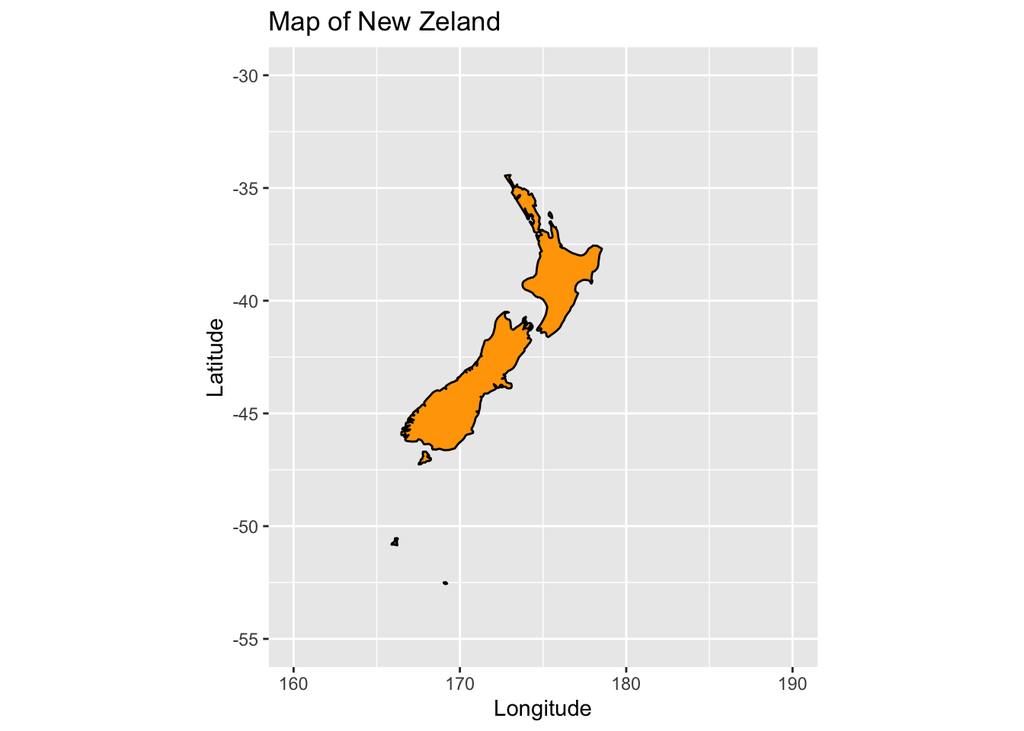

```r
nz_maps <- map_data("world", region = "New Zealand")

ggplot(nz_maps, aes(long, lat))+
  geom_polygon(aes(group=group), color ="black", fill = "orange")+
  xlim(c(160,190))+
  ylim(c(-55,-30))+
  coord_quickmap()+
  xlab("Longitude")+
  ylab("Latitude")+
  ggtitle("Map of New Zeland")
```

# Use the `sf` package

```r
#LOAD DATA
library(spData) #this packages contains the dataset (with sf objects) that we will be using today
data("nz")
data("us_states")
data("us_counties")
```

# 2.

Use the `sf` package to create a map of New Zealand. To access `sf` geometries for New Zealand use the “nz” dataset loaded above. The land should be some shade of orange.

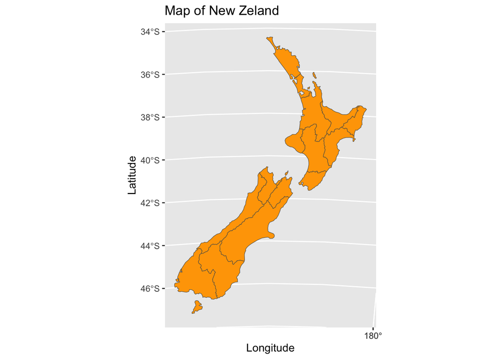

```r
ggplot(nz)+
  geom_sf(fill = "orange")+
   xlab("Longitude")+
  ylab("Latitude")+
  ggtitle("Map of New Zeland")
```

# 3.

Name two differences between the two New Zealand maps you created above.

- The sf map has lines distinguishing the subregions.
- The sf map has slightly curved latitude lines.

# 4.

Use the `us_states` dataset from above to create a map of the US States. All the land map should be some shade of red.

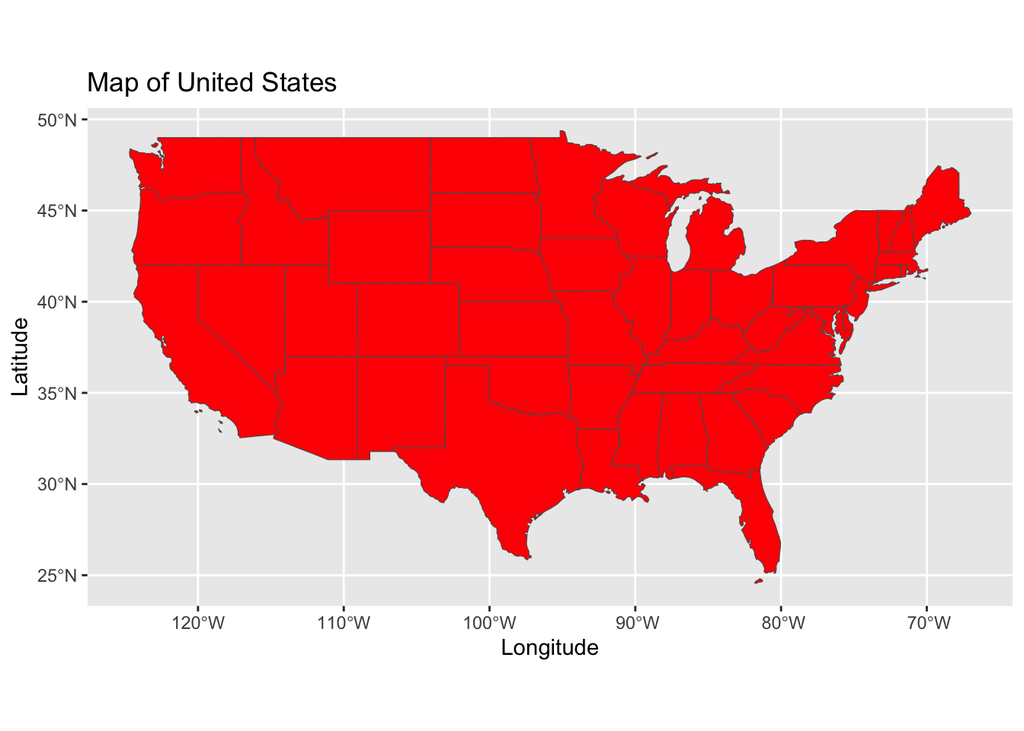

```r
ggplot(us_states)+
  geom_sf(fill = "red")+
   xlab("Longitude")+
  ylab("Latitude")+
  ggtitle("Map of United States")
```

# 5.

The `us_states` dataset has a column `REGION` which indicates whether the state is “Northeast”, “Midwest”, “South”, or “West”. Create a map which shades each state depending on the REGION it is located in.

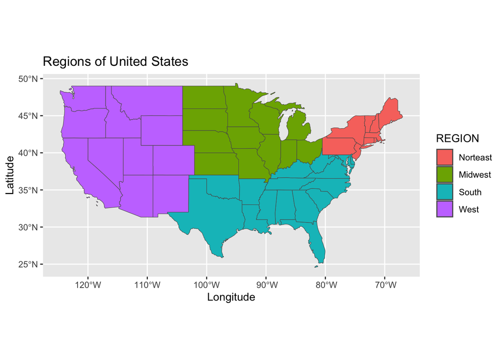

```r
 ggplot(us_states)+
  geom_sf(aes(fill = REGION))+
  xlab("Longitude")+
  ylab("Latitude")+
  ggtitle("Regions of United States")
```

# 6.

Create a cloropleth map which colors each state depending on the total population of that state in 2015 (`total_pop_15` column in the `us_states` dataset).

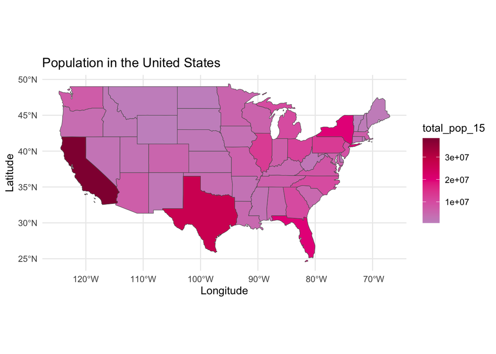

```r
library(RColorBrewer)

ggplot(us_states)+
  geom_sf(aes(fill = total_pop_15))+
    scale_fill_gradientn(colors = brewer.pal(8, "PuRd")[4:8]) +
  theme_minimal()+
   xlab("Longitude")+
  ylab("Latitude")+
  ggtitle("Population in the United States")
```

Suppose we wish to incorporate data from another source on each state. This will require us to join the `sf` data with another dataset (remember joins from before?).

```r
#dataset which contains information about each state
data(state)
state_data <- data.frame(state.x77)
#weirdly, the state names are listed as row names instead of in their own column. The below code fixes this.
state_data$NAME <- rownames(state_data)
```

# 7.

Join together the `state_data` dataset with the `sf` data housed in `us_states` into a new dataset called `states_map_data`. The key variable is the state name.

```r
states_map_data <- us_states %>%
  inner_join(state_data, by = "NAME")
```

# 8.

Note that in the previous step we lost one data row. What was it?

`states_map_data` will contain all the contential US states, but not the District of Columbia.

# 9.

Ignoring the fact that we lost one row, use your new dataset `states_map_data` (from 7) to create a cloropleth map which colors each state depending on the illiteracy rate in 1970 as a percent of the population (`Illiteracy`). Use any color palette you like.

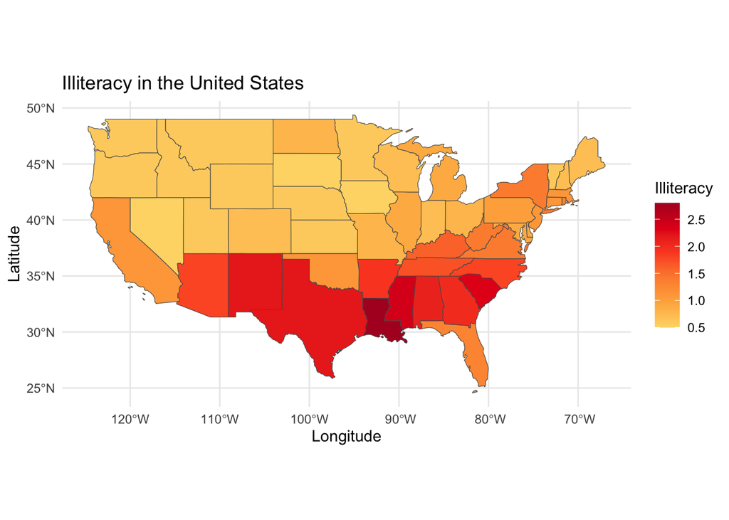

```r
ggplot(states_map_data)+
  geom_sf(aes(fill = Illiteracy))+
    scale_fill_gradientn(colors = brewer.pal(8, "YlOrRd")[3:8]) +
  theme_minimal()+
   xlab("Longitude")+
  ylab("Latitude")+
  ggtitle("Illiteracy in the United States")
```

Back to top